# Tidying data: pivot_wider

```r
library(tidyverse)
library(GLMsData)
data(blocks)
```

## Tidy data

All the major functions in the `ggplot2` and `dplyr` packages (among many others) assume that your data is in a **tidy** format, meaning that:

- each data set holds one and only one type of observation
- each column holds one and only one variable
- each row holds one and only one observation

When a set doesn’t have these properties, we begin by reshaping it. Many of the best tools for doing this are included in the `tidyr` package, including `pivot_wider`, which is useful when variable names are found in the cells of a spreadsheet

## The `blocks` dataset

The `GLMsData::blocks` set includes data from a block-stacking experiment in 1931 in which 25 children stacked 2 sorts of blocks in two trials each. Currently, each row represents one child in one trial with one shape, which is logical for many purposes.

```r
glimpse(blocks)
```

```
Rows: 100
Columns: 6
$ Child  <fct> A, B, C, D, E, F, G, H, I, J, K, L, M, N, O, P, Q, R, S, T, U, …
$ Number <int> 11, 9, 8, 9, 10, 13, 10, 7, 6, 12, 6, 9, 8, 7, 9, 9, 8, 7, 8, 4…
$ Time   <dbl> 30.0, 19.0, 18.6, 23.0, 29.0, 178.0, 42.0, 20.2, 12.0, 39.2, 14…
$ Trial  <int> 1, 1, 1, 1, 1, 1, 1, 1, 1, 1, 1, 1, 1, 1, 1, 1, 1, 1, 1, 1, 1, …
$ Shape  <fct> Cube, Cube, Cube, Cube, Cube, Cube, Cube, Cube, Cube, Cube, Cub…
$ Age    <dbl> 4.67, 5.00, 4.42, 4.33, 4.33, 4.83, 4.42, 5.00, 3.58, 4.00, 4.5…
```

Sometimes, however, we might need to consider an observation to consist of a single child (25 observations total) or a single child on a single trial (50 observations total). In these cases, we expect separate columns for each trial (both examples) and possibly for each shape as well (first example only).

## How to `pivot_wider`

To pivot a too-long data set like this, we need to specify 3 things:

- the variables (columns) that uniquely identify observations.
- The column(s) whose cells currently contain variable names
- The column(s) whose cells currently contain the corresponsing variable values.

The following chunk reshapes `blocks` so that each child represents a single observation. This means that `Trial` and `Shape` are no longer values of variables that help identify observations. Instead, their values should be incorporated into column names, like so:

```r
blocks_kids <- blocks |>
  pivot_wider(id_cols = Child,
              names_from = c(Trial, Shape),
              values_from = c(Number, Time))
glimpse(blocks_kids)
```

```
Rows: 25
Columns: 9
$ Child             <fct> A, B, C, D, E, F, G, H, I, J, K, L, M, N, O, P, Q, R…
$ Number_1_Cube     <int> 11, 9, 8, 9, 10, 13, 10, 7, 6, 12, 6, 9, 8, 7, 9, 9,…
$ Number_1_Cylinder <int> 6, 4, 5, 4, 6, 8, 5, 6, 6, 5, 5, 7, 5, 6, 5, 6, 5, 7…
$ Number_2_Cube     <int> 10, 10, 7, 11, 6, 13, 9, 6, 6, 11, 7, 9, 7, 9, 9, 11…
$ Number_2_Cylinder <int> 8, 5, 5, 6, 5, 9, 5, 4, 6, 8, 6, 5, 6, 5, 5, 5, 8, 6…
$ Time_1_Cube       <dbl> 30.0, 19.0, 18.6, 23.0, 29.0, 178.0, 42.0, 20.2, 12.…
$ Time_1_Cylinder   <dbl> 30.0, 6.0, 14.2, 8.2, 14.0, 52.4, 14.0, 22.2, 16.6, …
$ Time_2_Cube       <dbl> 35.0, 28.0, 18.0, 34.8, 16.2, 82.4, 21.6, 16.8, 15.4…
$ Time_2_Cylinder   <dbl> 125.0, 14.4, 24.0, 14.4, 15.0, 44.6, 10.8, 18.0, 16.…
```

## Another `blocks` pivot

The following chunk reshapes `blocks` so that observations are defined to be a single child stacking a single shape of block, so `Trial` is no longer an identifying variable.

```r
blocks_kidshape <- blocks |>
  pivot_wider(id_cols = c(Child, Shape),
              names_from = Trial,
              values_from = c(Number, Time))
glimpse(blocks_kidshape)
```

```
Rows: 50
Columns: 6
$ Child    <fct> A, B, C, D, E, F, G, H, I, J, K, L, M, N, O, P, Q, R, S, T, U…
$ Shape    <fct> Cube, Cube, Cube, Cube, Cube, Cube, Cube, Cube, Cube, Cube, C…
$ Number_1 <int> 11, 9, 8, 9, 10, 13, 10, 7, 6, 12, 6, 9, 8, 7, 9, 9, 8, 7, 8,…
$ Number_2 <int> 10, 10, 7, 11, 6, 13, 9, 6, 6, 11, 7, 9, 7, 9, 9, 11, 9, 7, 5…
$ Time_1   <dbl> 30.0, 19.0, 18.6, 23.0, 29.0, 178.0, 42.0, 20.2, 12.0, 39.2, …
$ Time_2   <dbl> 35.0, 28.0, 18.0, 34.8, 16.2, 82.4, 21.6, 16.8, 15.4, 46.4, 2…
```

There are many optional arguments that may be helpful in obtaining more descriptive column names, including `names_sep`.

```r
blocks_kidshape <- blocks |>
  pivot_wider(id_cols = c(Child, Shape),
              names_from = Trial,
              values_from = c(Number, Time),
              names_sep = "_Trial_")
glimpse(blocks_kidshape)
```

```
Rows: 50
Columns: 6
$ Child          <fct> A, B, C, D, E, F, G, H, I, J, K, L, M, N, O, P, Q, R, S…
$ Shape          <fct> Cube, Cube, Cube, Cube, Cube, Cube, Cube, Cube, Cube, C…
$ Number_Trial_1 <int> 11, 9, 8, 9, 10, 13, 10, 7, 6, 12, 6, 9, 8, 7, 9, 9, 8,…
$ Number_Trial_2 <int> 10, 10, 7, 11, 6, 13, 9, 6, 6, 11, 7, 9, 7, 9, 9, 11, 9…
$ Time_Trial_1   <dbl> 30.0, 19.0, 18.6, 23.0, 29.0, 178.0, 42.0, 20.2, 12.0, …
$ Time_Trial_2   <dbl> 35.0, 28.0, 18.0, 34.8, 16.2, 82.4, 21.6, 16.8, 15.4, 4…
```

## A dumbbell plot

As an application of this, we might want to create a dumbbell plot comparing the number of cylindrical blocks stacked in the first vs second trial.

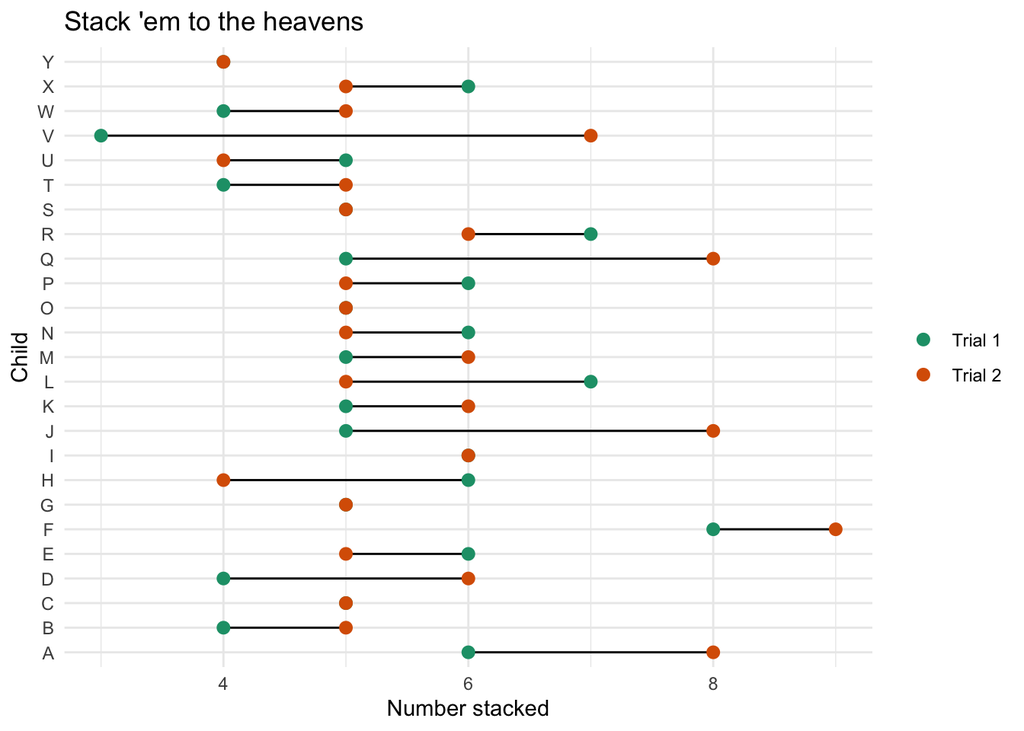

```r
blocks_kidshape |>
  filter(Shape == "Cylinder") |>
  ggplot() +
  geom_segment(aes(x = Number_Trial_1,
                   y = Child,
                   xend = Number_Trial_2,
                   yend = Child)) +
  geom_point(aes(x = Number_Trial_1,
                 y = Child,
                 color = "Trial 1"),
             size = 2.5) +
  geom_point(aes(x = Number_Trial_2,
                 y = Child,
                 color = "Trial 2"),
             size = 2.5) +
  labs(x = "Number stacked",
       color = NULL,
       title = "Stack 'em to the heavens") +
  scale_color_brewer(palette = "Dark2") +
  theme_minimal()
```